# Assignment2

Rabin Paudel

9/15/2021

## Problem 1(30 pts)

#### We can instill this library and load the dataset using the

#### folowing code chunk.

```r
library(nycflights13)
flights
```

```
## # A tibble: 336,776 x 19
##     year month   day dep_time sched_dep_time dep_delay arr_time sched_arr_time
##    <int> <int> <int>    <int>          <int>     <dbl>    <int>          <int>
##  1  2013     1     1      517            515         2      830            819
##  2  2013     1     1      533            529         4      850            830
##  3  2013     1     1      542            540         2      923            850
##  4  2013     1     1      544            545        -1     1004           1022
##  5  2013     1     1      554            600        -6      812            837
##  6  2013     1     1      554            558        -4      740            728
##  7  2013     1     1      555            600        -5      913            854
##  8  2013     1     1      557            600        -3      709            723
##  9  2013     1     1      557            600        -3      838            846
## 10  2013     1     1      558            600        -2      753            745
## # … with 336,766 more rows, and 11 more variables: arr_delay <dbl>,
## #   carrier <chr>, flight <int>, tailnum <chr>, origin <chr>, dest <chr>,
## #   air_time <dbl>, distance <dbl>, hour <dbl>, minute <dbl>, time_hour <dttm>
```

```r
library(ggplot2)
library(dplyr)
```

### Q.N.1

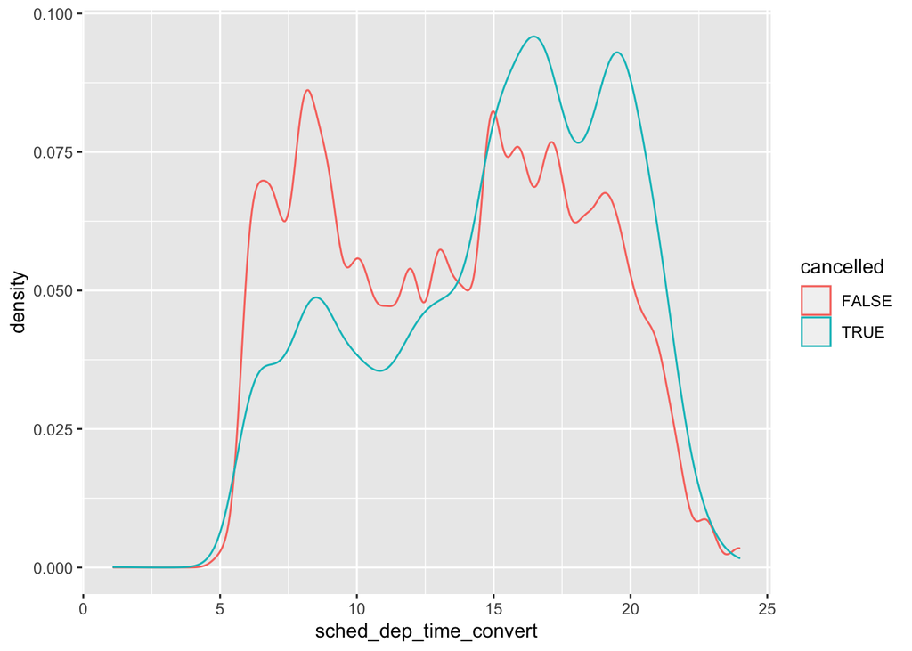

```r
fligh <-
  flights %>%
  mutate(
    cancelled = is.na(dep_time),
    sched_dep_time_convert = hour + minute / 60
  )
fligh %>%
  ggplot(aes(sched_dep_time_convert, colour = cancelled)) +
  geom_density()
```

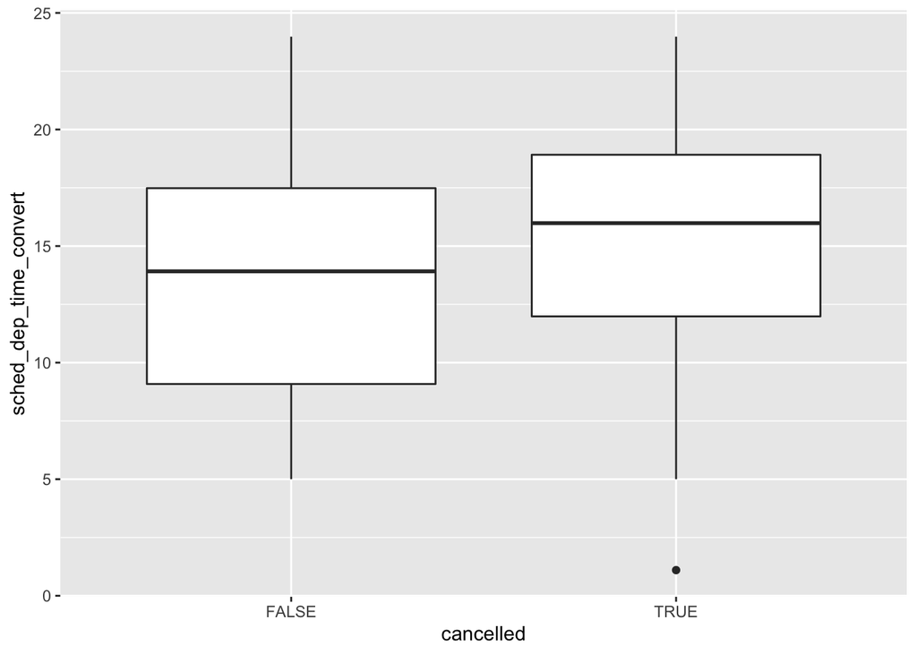

```r
fligh %>%
  ggplot(aes(cancelled, sched_dep_time_convert)) +
  geom_boxplot()
```

### Q.N.2

#### Boxplot of the temperatures, grouped by months.

```r
weather
```

```
## # A tibble: 26,115 x 15
##    origin  year month   day  hour  temp  dewp humid wind_dir wind_speed
##    <chr>  <int> <int> <int> <int> <dbl> <dbl> <dbl>    <dbl>      <dbl>
##  1 EWR     2013     1     1     1  39.0  26.1  59.4      270      10.4
##  2 EWR     2013     1     1     2  39.0  27.0  61.6      250       8.06
##  3 EWR     2013     1     1     3  39.0  28.0  64.4      240      11.5
##  4 EWR     2013     1     1     4  39.9  28.0  62.2      250      12.7
##  5 EWR     2013     1     1     5  39.0  28.0  64.4      260      12.7
##  6 EWR     2013     1     1     6  37.9  28.0  67.2      240      11.5
##  7 EWR     2013     1     1     7  39.0  28.0  64.4      240      15.0
##  8 EWR     2013     1     1     8  39.9  28.0  62.2      250      10.4
##  9 EWR     2013     1     1     9  39.9  28.0  62.2      260      15.0
## 10 EWR     2013     1     1    10  41    28.0  59.6      260      13.8
## # … with 26,105 more rows, and 5 more variables: wind_gust <dbl>, precip <dbl>,
## #   pressure <dbl>, visib <dbl>, time_hour <dttm>
```

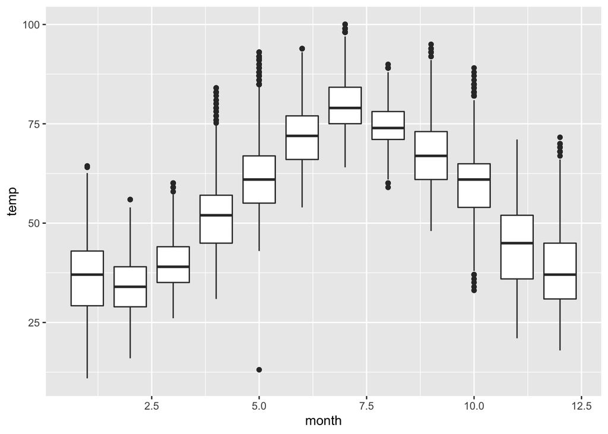

```r
ggplot(weather, aes(x = month, y = temp, group = month)) +
geom_boxplot(na.rm = TRUE)
```

#### Second way without ggplot

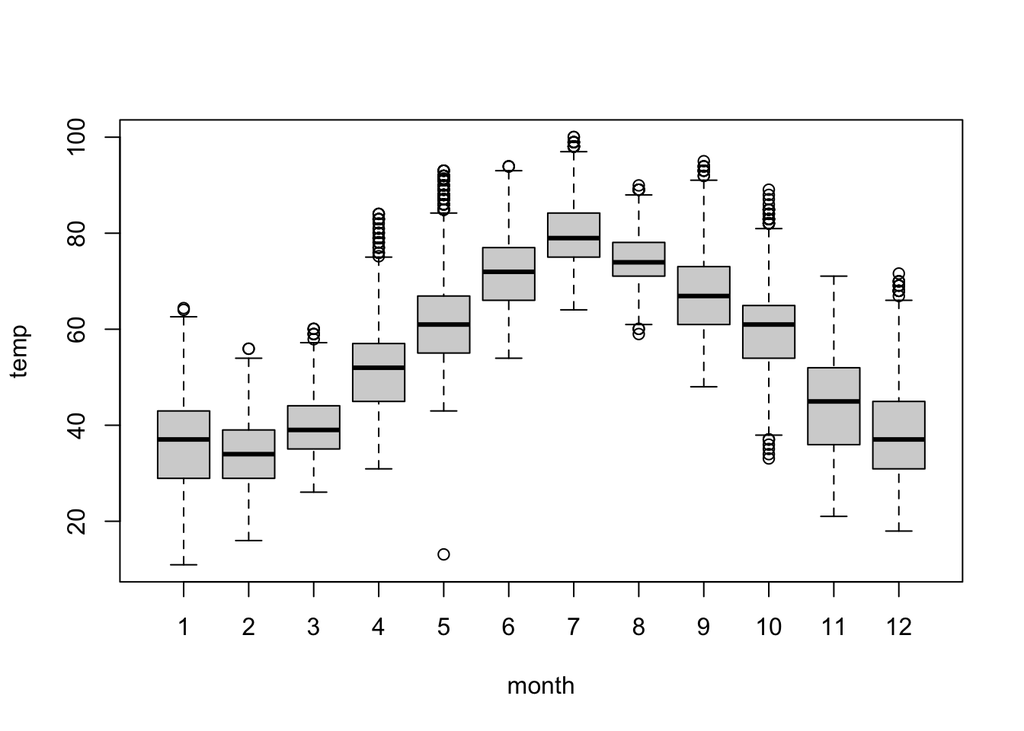

```r
boxplot(data = weather, temp~month)
```

### Q.N.3

#### Visualize the proportion of cancelled flights each day aginst the average

#### daily temp. group by airports of origin (EWR, JFK, LGA).

```r
cancelled_flights <- flights %>% group_by(origin) %>%
  summarize(pct_cancelled = mean(is.na(arr_delay) |is.na(dep_delay)))

average_temp <- weather %>% group_by(origin) %>% summarize(avg_temp = mean(temp,
                                                                na.rm =TRUE))
cancelled_flights %>% mutate(newDay = as.numeric(as.Date(paste(2013,2,24,
  sep="/"),format="%Y/%m/%d") -as.Date("2013/01/01",format="%Y/%m/%d")))
```

```
## # A tibble: 3 x 3
##   origin pct_cancelled newDay
##   <chr>          <dbl>  <dbl>
## 1 EWR           0.0307     54
## 2 JFK           0.0198     54
## 3 LGA           0.0337     54
```

```r
average_temp %>% mutate(newDa = as.numeric(as.Date(paste(2013,3,25,
  sep="/"),format="%Y/%m/%d") -as.Date("2013/01/01",format="%Y/%m/%d")))
```

```
## # A tibble: 3 x 3
##   origin avg_temp newDa
##   <chr>     <dbl> <dbl>
## 1 EWR        55.5    83
## 2 JFK        54.5    83
## 3 LGA        55.8    83
```

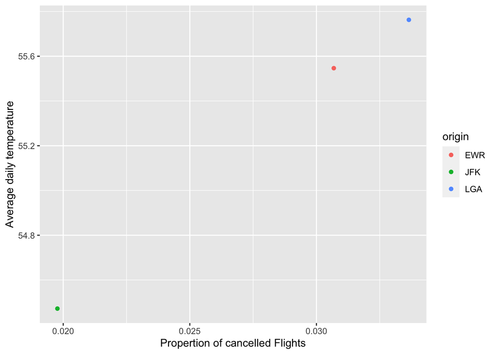

```r
combine_data <- left_join(cancelled_flights, average_temp, by = "origin")

data_visualize <- ggplot(data = combine_data) +
  geom_point(mapping = aes(x = pct_cancelled, y = avg_temp, color = origin)) +
  xlab("Propertion of cancelled Flights") + ylab("Average daily temperature")
data_visualize
```

### Q.N.4

#### Visualize the arrival delay for flights to the top twenty most popular

#### destinations, grouped by destinations.

```r
flights %>% group_by(dest) %>%
  filter(n() > 365, arr_delay > 743) %>%
  summarise(dest) %>% count()
```

```
## # A tibble: 21 x 2
## # Groups:   dest [21]
##    dest      n
##    <chr> <int>
##  1 ATL       3
##  2 BWI       1
##  3 CLT       1
##  4 CMH       1
##  5 CVG       1
##  6 DEN       1
##  7 HNL       1
##  8 IAH       1
##  9 LAS       2
## 10 LAX       1
## # … with 11 more rows
```

```r
FRAME <- filter(flights, arr_delay >743) %>% group_by(dest)
FRAME
```

```
## # A tibble: 29 x 19
## # Groups:   dest [21]
##     year month   day dep_time sched_dep_time dep_delay arr_time sched_arr_time
##    <int> <int> <int>    <int>          <int>     <dbl>    <int>          <int>
##  1  2013     1     1      848           1835       853     1001           1950
##  2  2013     1     9      641            900      1301     1242           1530
##  3  2013     1    10     1121           1635      1126     1239           1810
##  4  2013    11     3      603           1645       798      829           1913
##  5  2013    12     5      756           1700       896     1058           2020
##  6  2013    12    14      830           1845       825     1210           2154
##  7  2013    12    17      705           1700       845     1026           2020
##  8  2013    12    19      734           1725       849     1046           2039
##  9  2013     2    10     2243            830       853      100           1106
## 10  2013     2    16      757           1930       747     1013           2149
## # … with 19 more rows, and 11 more variables: arr_delay <dbl>, carrier <chr>,
## #   flight <int>, tailnum <chr>, origin <chr>, dest <chr>, air_time <dbl>,
## #   distance <dbl>, hour <dbl>, minute <dbl>, time_hour <dttm>
```

#### Try to find top twenty most popular destination.

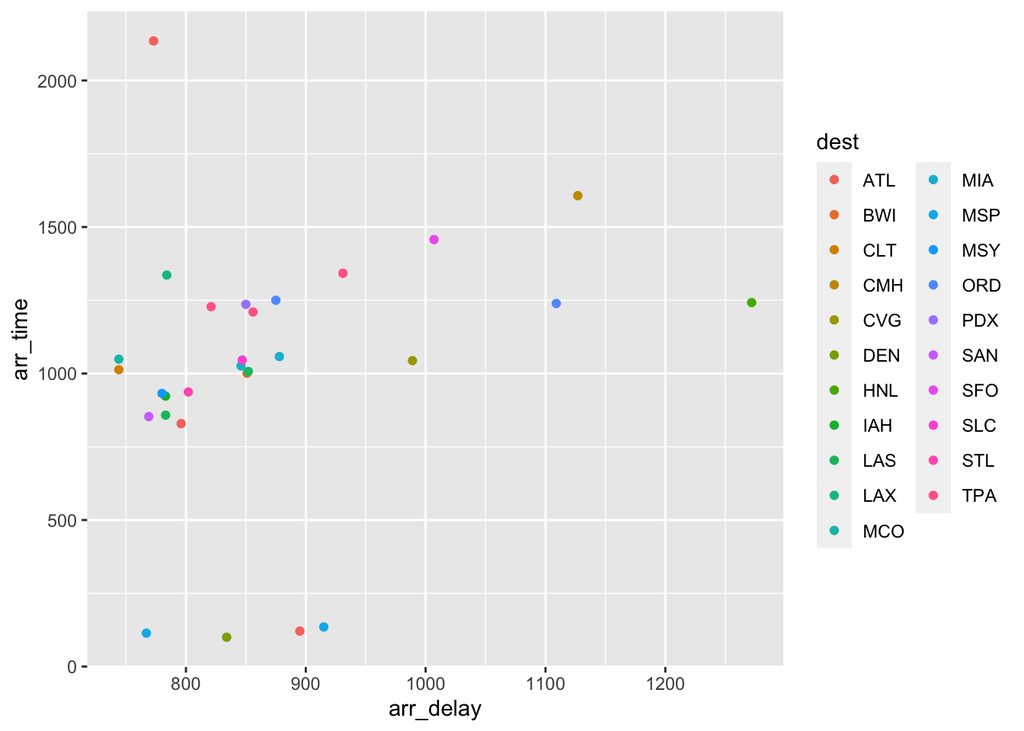

```r
ggplot(data = FRAME) +
  geom_point(mapping = aes(x = arr_delay, y = arr_time, color = dest))
```

## Problem 2 (20pts)

```r
library(dplyr)
library(tidyverse)
library(RColorBrewer)
library(dslabs)
```

### 10.15 Exercise

#### Q.N.1.Reproduce the image plot we previously made now for smallpox.For this

#### plot, do not include years in which cases were not reported in 10 or more

#### weeks.

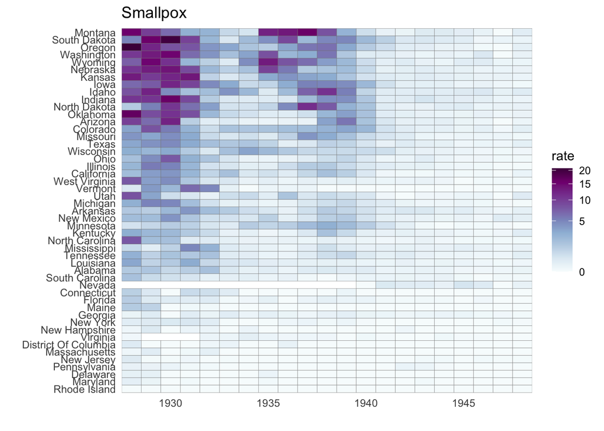

```r
the_disease <- "Smallpox"
dat <- us_contagious_diseases %>%
  filter(!state%in%c("Hawaii", "Alaska") & disease == the_disease & weeks_reporting >= 10) %>%
  mutate(rate = count/population *10000) %>%
  mutate(state = reorder(state, rate))

dat %>% ggplot(aes(year, state, fill = rate)) +
  geom_tile(color = "grey50") +
  scale_x_continuous(expand = c(0,0)) +
  scale_fill_gradientn(colors = brewer.pal(9,"BuPu"), trans = "sqrt") +
  theme_minimal() +
  theme(panel.grid = element_blank()) +
        ggtitle(the_disease) +
        ylab("") + xlab("")
```

#### following the instructions of the previous question for smallpox.

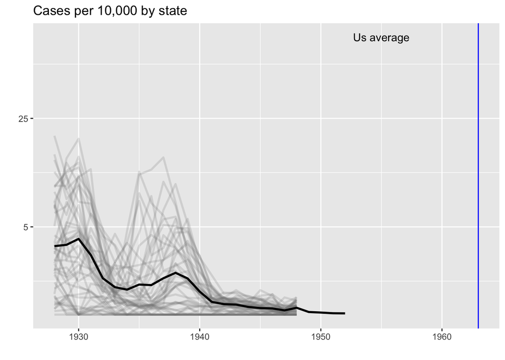

```r
the_disease <- "Smallpox"
dat <- us_contagious_diseases %>%
  filter(!state%in%c("Hawaii", "Alaska") & disease == the_disease & weeks_reporting >= 10) %>%
  mutate(rate = count/population *10000) %>%
  mutate(state = reorder(state, rate))

avg <- us_contagious_diseases %>%
  filter(disease == the_disease) %>% group_by(year) %>%
  summarize(us_rate = sum(count, na.rm = TRUE)/
              sum(population, na.rm = TRUE) * 10000)
dat %>% filter(!is.na(rate)) %>% ggplot() +
  geom_line(aes(year, rate, group = state), color = "grey50",
            show.legend = FALSE, alpha = 0.2, size = 1) +
  geom_line(mapping = aes(year, us_rate), data = avg, size = 1) +
  scale_y_continuous(trans = "sqrt", breaks = c(5,25,125,300)) +
  ggtitle("Cases per 10,000 by state") +
  xlab("") + ylab("")+
geom_text(data = data.frame(x = 1955, y = 50),
          mapping = aes(x,y,label = "Us average"),
          color = "black") +
  geom_vline (xintercept = 1963, col = "blue")
```

#### Q.N.3.For the state of California, make a time series plot showing rates

#### for all diseases. Include only years with 10 or more weeks reporting.

#### Use a different color for each disease. Help of #4 we done (rate by using

#### summarize the total divided by total Pop).

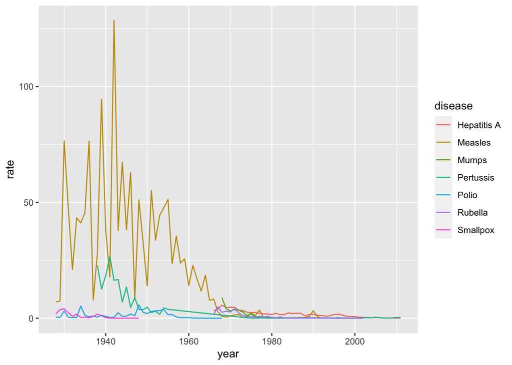

```r
us_contagious_diseases %>% filter(state == "California" &
                                    weeks_reporting >= 10) %>%
  group_by(year,disease) %>%
  summarize(rate = sum(count)/sum(population) * 10000) %>%
  ggplot(aes(year,rate,color = disease)) + geom_line()
```

#### Q.N.4 Now do the same for the rates for the US. Hint compute the US rate by

#### using summarize: total divided by population.Same way #3 need filter to

#### find all data

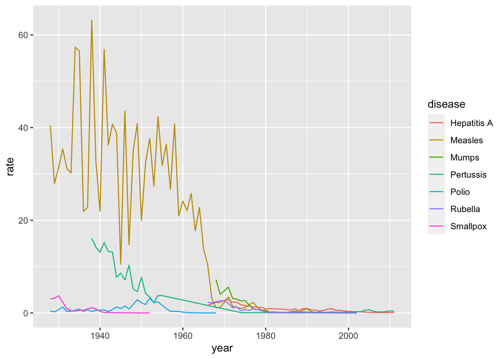

```r
us_contagious_diseases %>% filter(!is.na(population))%>%
  group_by(year,disease) %>%
  summarize(rate = sum(count)/sum(population) * 10000) %>%
  ggplot(aes(year,rate,color = disease)) + geom_line()
```

## Problem 3 (25)

#### This problem uses the obesity data from the CDC. The original data is in

#### Excel format and we had uploaded a copy of this file onto Moodle. First

#### download the data onto your desktop/laptop work space and extract the data

#### if the readxl library is missing.

```r
library(readxl)
library(socviz)
library(dplyr)
fname <- "/Users/rabinpaudel/Desktop/HW2/obesity_data.xlsx"
wrkbk <- read_excel(fname)
```

```
## * `` -> ...2
## * `` -> ...3
## * `` -> ...5
## * `` -> ...6
## * `` -> ...7
## * ...
```

```r
obesity_2012 <- setNames(wrkbk[-1, c(2, 61)], c("fips", "pct"))
obesity_2012$pct <- as.numeric(obesity_2012$pct) / 100
gh2 <- setNames(data.frame( as.numeric(obesity_2012$fips),obesity_2012$pct ),
                c("fips", "pct"))
```

#### Try to Join Two data set.

```r
gh <- left_join(county_map, county_data, by = "id")
Join_ALL_Data<- left_join(gh, gh2, by = "fips", na.rm = TRUE)
```

#### here is code

```r
CORR <- cor(Join_ALL_Data$pct, Join_ALL_Data$hh_income)
CORR
```

```
## [1] -0.4643518
```

#### -0.4643518 (hh_income)

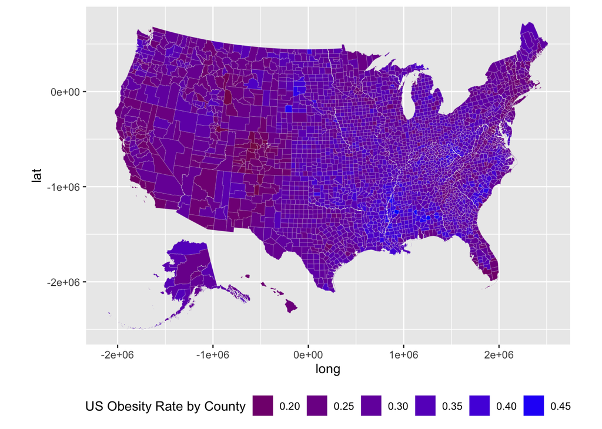

```r
library(ggplot2)
library(maps)
p <- ggplot(Join_ALL_Data, aes(x = long, y = lat, group = group, fill = pct))
p1 <- p + geom_polygon(color = "gray90", size = 0.05) + coord_equal()
p2 <- p1 + scale_fill_gradient2(low = "brown1",
                        mid = scales::muted("red"),
                        high = "blue", breaks = c(0.2,0.25,0.3,0.35,0.40,0.45))
p3 <- p2 + labs(fill = "US Obesity Rate by County") +
  guides(fill = guide_legend(nrow = 1)) +
  theme(legend.position = "bottom")
p3
```